# Variable importance across the Danish bird atlases

November 2 models: means and distributions across species

# 1 What we set out to examine

We first summarised environmental variable importance using the mean variance partition (VP) across species in each atlas. We then expanded the comparison to show the full distribution of species-level estimates. A mean can change because many species shift slightly, a few species shift substantially, or both. Looking at the distributions helps distinguish these possibilities, although identifying the species responsible requires keeping their identities in the comparison.

This report describes the figures we have produced. It does **not** present a formal test of temporal change or propagate posterior uncertainty.

# 2 Data and calculations

All figures use the model set **`2026-11-02_06-55-21`**, with one fitted model for each atlas: the 1970s, 1990s, and 2010s. Inputs are the `parameter_estimates_VP_.csv` exports in each model’s `Results` directory under `data-new/2-hmsc/derived/models`.

There are **155 matched species in every atlas**, with no species omitted from these plots. Each species receives equal weight in the distributions and means. The ten environmental predictors are temperature, precipitation, land-use heterogeneity, urban cover, cropland cover, pasture cover, grass/shrubland cover, and three separate forest-cover predictors: deciduous, evergreen, and mixed/other forest. These forest types replace the single forest predictor in the older model.

The site-level random effect is excluded from the displayed panels and Sankey. It remains part of the original VP denominator: we have **not** renormalised the environmental predictors to sum to 100%. The environmental components plus the site random effect sum to one for each species and atlas.

## 2.1 Two scales of variable importance

**Relative VP** describes the allocation of model-explained variation among the environmental predictors and the spatial component. In the figures, it is expressed as a percentage. A value of 10% means that the predictor receives one tenth of that species’ partitioned model-explained variation; it does not mean 10% of all observed variation in occurrence.

**Tjur R²-scaled VP** multiplies each species’ relative VP by that species’ exported Tjur R² before plotting or averaging:

$$\mathrm{scaled\ VP}_{s,v,a}
= \mathrm{relative\ VP}_{s,v,a}\times\mathrm{Tjur\ R}^{2}_{s,a}.$$

Here, $s$ denotes species, $v$ predictor, and $a$ atlas. Both plotted scales are multiplied by 100 for display. Scaling matches the existing Sankey figure. It combines the predictor’s VP allocation with species-level model fit; it is an operational scaling, rather than a separate estimate of causal contribution or a newly fitted variance decomposition.

Consequently, scaled VP can change because relative VP changes, Tjur R² changes, or both. Comparing both scales helps reveal whether a pattern also appears without the model-fit scaling.

## 2.2 Checks performed

The plotting script checks that all three atlases contain the same 155 unique species, aligns their columns by species identity, and checks all ten predictors are present. Unexpected predictors cause an error instead of being silently excluded. Values must be finite and between zero and one, and the unscaled partitions must sum to one including the spatial component. The species means of scaled VP were also checked against all 30 Sankey ribbon widths.

# 3 Starting point: mean importance

The Sankey bump chart shows the **mean scaled VP across the 155 species** for each predictor and atlas. Ribbon thickness represents the mean contribution, while the ordering follows relative importance. The total height includes environmental predictors only. The ribbons connect atlas summaries; they do not track flows of species or ecological quantities between atlases.

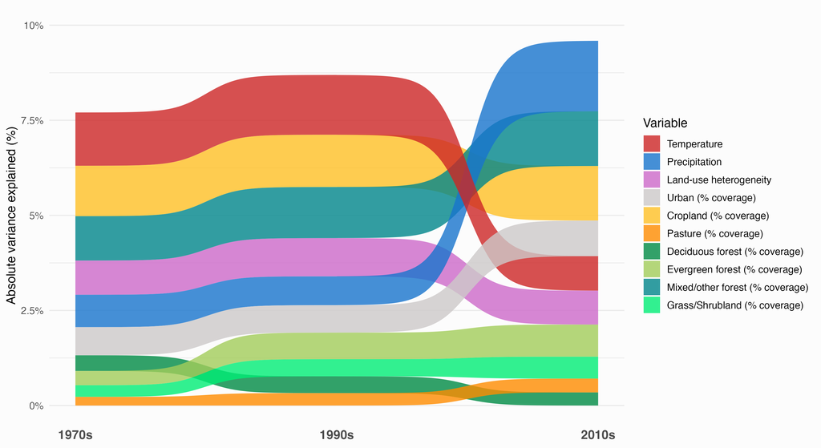

Mean Tjur R²-scaled VP across species, with separate forest-cover predictors and no effect-size panels.

# 4 Full distributions across species

Each curve below is based on **155 species-level exported estimates** for one predictor in one atlas. These are distributions **across species**, not posterior distributions, and curve widths do not represent uncertainty about an estimate. Blue denotes the 1970s, orange the 1990s, and green the 2010s throughout.

## 4.1 Relative VP: density curves

A density curve shows where species’ VP estimates are concentrated. Curves shifted to the right indicate larger VP values; longer right tails indicate a subset of species with relatively high importance. Density height is not a percentage of species: the area under a curve represents a proportion, and the whole curve integrates approximately to one.

We use Gaussian kernel densities with reflection at the boundaries of 0 and 100 percentage points. For each predictor and VP scale, a single bandwidth is selected using `bw.nrd0` on the pooled values from the three atlases, and used for all three curves. This avoids introducing atlas differences through different smoothing settings. Densities are evaluated on a shared 2,048-point grid within each panel, covering every estimate and extending four bandwidths beyond the largest value where the upper boundary permits. Their numerical integrals are checked to be within 0.01 of one.

Both horizontal and vertical axis ranges vary among density panels. Compare atlases **within a panel**; peak heights across predictors are not a ranking of importance. Small bumps depend on bandwidth and should not be treated as established ecological groups.

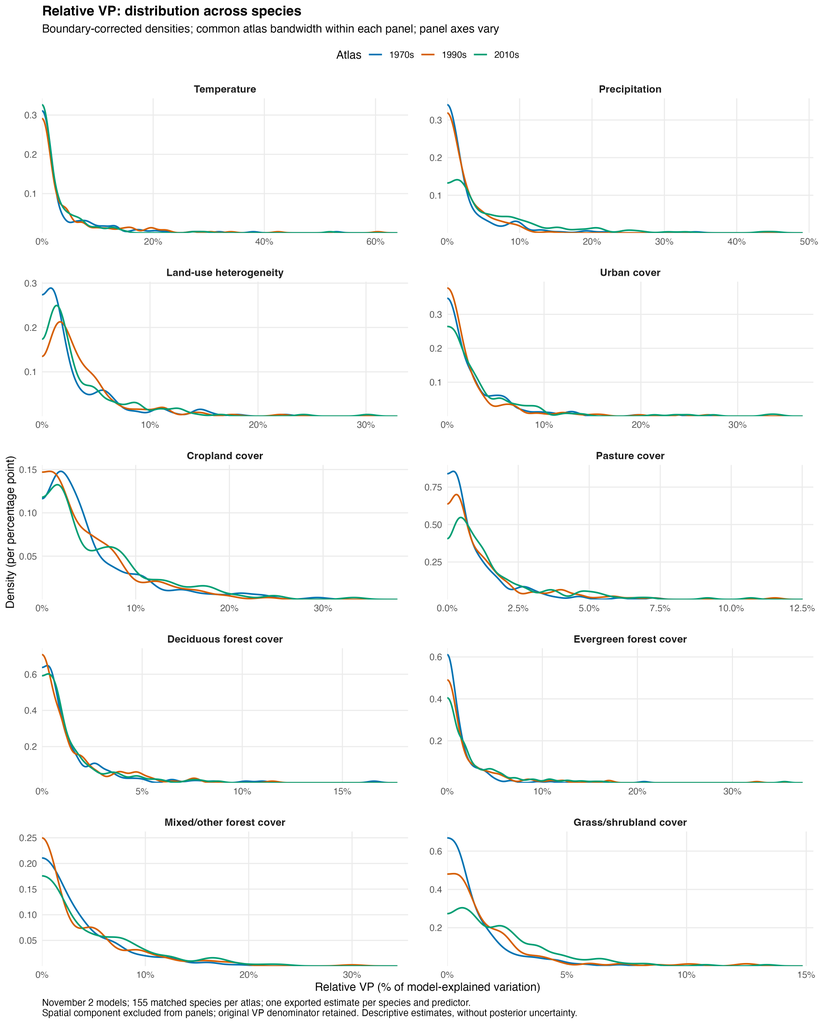

Distributions of relative VP across the same 155 species, with common smoothing across atlases within each predictor.

## 4.2 Relative VP: cumulative distributions

The empirical cumulative distribution function (ECDF) shows the percentage of species with VP **at or below** a given value. For example, a height of 75% at VP = 5% means that 75% of the species have relative VP no greater than 5%. At a given horizontal value, a lower curve means fewer species fall below that threshold, consistent with generally larger VP values. Crossing curves indicate that the difference is not a uniform shift across the distribution.

These curves use the estimates directly, without smoothing. Horizontal ranges vary among predictors, while the vertical scale is always 0–100% of species.

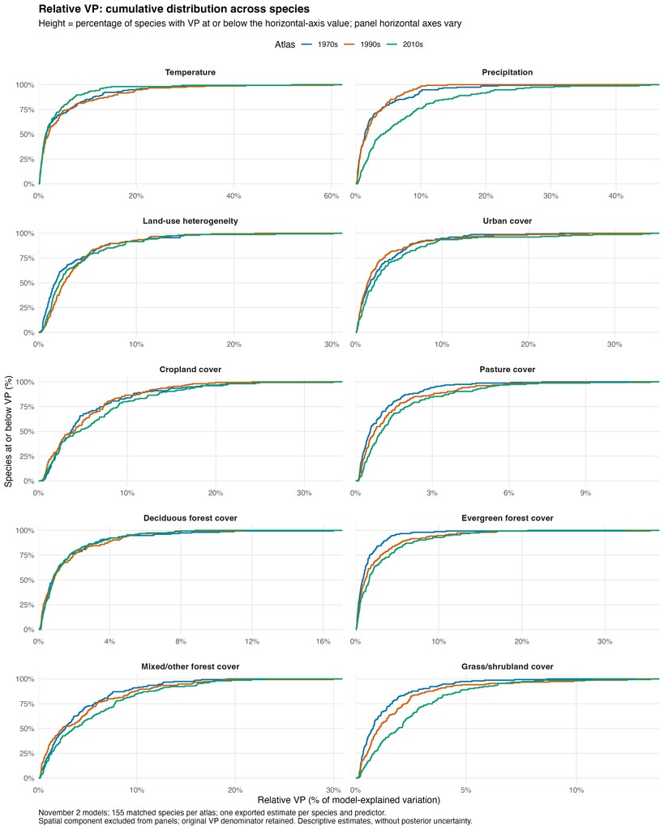

Empirical cumulative distributions of relative VP; each atlas contains 155 species.

The following medians provide numerical context. Values are percentage points on the relative-VP scale; they are descriptive summaries without uncertainty intervals.

Median relative VP (%) across species.

| Predictor | 1970s | 1990s | 2010s |
| --- | --- | --- | --- |
| Temperature | 1.622 | 2.054 | 1.463 |
| Precipitation | 1.415 | 1.699 | 4.248 |
| Land-use heterogeneity | 1.691 | 2.579 | 2.103 |
| Urban cover | 1.717 | 1.415 | 2.180 |
| Cropland cover | 3.691 | 3.911 | 4.660 |
| Pasture cover | 0.569 | 0.736 | 1.015 |
| Deciduous forest cover | 0.780 | 0.867 | 0.812 |
| Evergreen forest cover | 0.823 | 1.149 | 1.631 |
| Mixed/other forest cover | 2.735 | 2.412 | 3.542 |
| Grass/shrubland cover | 0.788 | 1.073 | 1.937 |

## 4.3 Tjur R²-scaled VP: density curves

These figures repeat the comparison after applying the species-specific Tjur R² scaling. The values are generally smaller because the relative partitions are multiplied by model-fit values between zero and one. Differences from the relative-VP plots therefore also reflect variation in model fit across species and atlases.

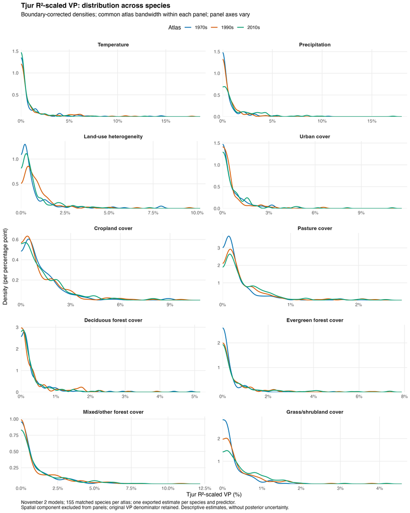

Density curves of Tjur R²-scaled VP across species, on the same scale used to calculate the Sankey means.

## 4.4 Tjur R²-scaled VP: cumulative distributions

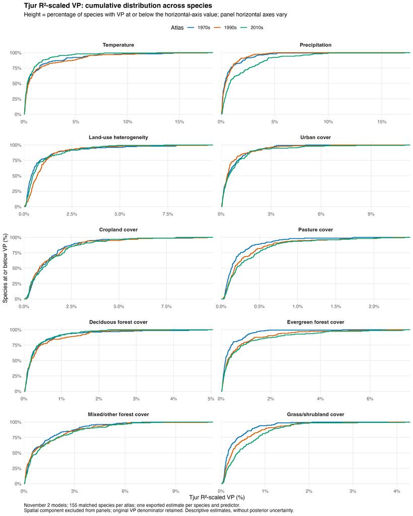

Empirical cumulative distributions of Tjur R²-scaled VP across species.

Median Tjur R²-scaled VP (%) across species.

| Predictor | 1970s | 1990s | 2010s |
| --- | --- | --- | --- |
| Temperature | 0.370 | 0.465 | 0.307 |
| Precipitation | 0.326 | 0.396 | 0.820 |
| Land-use heterogeneity | 0.383 | 0.684 | 0.472 |
| Urban cover | 0.384 | 0.363 | 0.468 |
| Cropland cover | 0.866 | 0.811 | 0.975 |
| Pasture cover | 0.136 | 0.177 | 0.201 |
| Deciduous forest cover | 0.184 | 0.202 | 0.184 |
| Evergreen forest cover | 0.177 | 0.259 | 0.299 |
| Mixed/other forest cover | 0.508 | 0.495 | 0.782 |
| Grass/shrubland cover | 0.162 | 0.247 | 0.373 |

# 5 What the figures suggest

Many predictors have strongly right-skewed distributions: most species have small VP values, while a smaller number have much higher values. This makes the distribution plots useful companions to the means in the Sankey.

The 2010s precipitation curve is visibly shifted towards higher values relative to the earlier atlases, on both scales. The ECDFs also suggest higher typical grass/shrubland VP in the later atlases. Some other predictors show overlapping or crossing curves, so their changes are less well described by a single community-wide increase or decrease. These observations are descriptive, and are not evidence of statistically supported change by themselves.

# 6 How we can approach temporal comparisons

## 6.1 Distribution change and species change answer different questions

A distribution comparison asks whether the collection of VP values across species changed in location, spread, or shape. A species-level comparison asks which species increased or decreased, and by how much. Neither requires the other as a preliminary test.

These questions can give different answers. If two species exchange VP values, their distribution remains identical even though both species changed. A useful next stage would therefore combine community summaries with paired species-level differences for the adjacent comparisons, 1970s–1990s and 1990s–2010s.

## 6.2 The exported estimates do not yet provide uncertainty for change

The current CSVs and saved VP summaries provide one value per species, predictor, and atlas. The spread shown here is among species, not uncertainty in those values. Formal model-based comparisons would require recovering VP uncertainty from the fitted posterior samples, checking convergence, and validating the calculation against the original Hmsc implementation.

The intended target would be the fixed set of 155 modelled species. Posterior draws should preserve the joint values across species within each atlas, rather than treating 155 estimates from a shared community model as independent data. The independently fitted atlas models also do not have naturally paired MCMC draw indices.

For each adjacent atlas comparison, useful quantities would include changes in the mean, median, selected quantiles, and individual species’ VP values. A whole-distribution distance could describe the magnitude of redistribution. Such a distance needs an interpretation in terms of a meaningful magnitude of change; being greater than zero alone is not an ecological conclusion.

We have not run an ordinary two-sample distribution test on the exported values. The same species occur in all atlases, their estimates share a fitted model, and the estimates have uncertainty that those tests would not automatically incorporate. A resampling test would need a clearly justified null and dependence structure before its p-values could be interpreted.

## 6.3 Interpretation requires care even after adding uncertainty

Relative VP is compositional: an increase in one component is accompanied by decreases elsewhere in the full partition. It also depends on the environmental variation represented in each atlas, as well as the fitted species–environment relationships. Changes in VP therefore do not establish changes in coefficients or causal effects. Scaled VP additionally depends on Tjur R².

The present figures are based on each fitted model’s inputs. They do not impose a new common-cell evaluation grid or hold environmental covariance constant. Those choices would need to be explicit if we later sought to separate changes in species responses from changes in the environments represented by the models.

# 7 Reproduction and current status

Knit this document to regenerate the Sankey and four distribution PNGs and embed them in a self-contained HTML report. The plotting scripts can also be run directly from the project root:

```r
source("scripts/5-vis/vp-distributions/vp-geom-sankey-bump.R")
source("scripts/5-vis/vp-distributions/vp-distributions.R")
```

The figures and this report remain in `scripts/5-vis/vp-distributions`. Only PNG plots are generated. Posterior VP reconstruction, convergence assessment for the proposed comparisons, uncertainty intervals, and formal change tests remain future work.